# Análisis de sentimiento

01/2023

## Introducción

Vamos a ver un ejemplo más avanzado aunque manteniendo la simplicidad en cuanto a nuestra aproximación analítica.

Una manera de analizar el sentimiento que expresa un texto es asignar a cada palabra una polaridad, esto si, si es positiva, negativa o neutra. El sentimiento de una oración sería la suma de las aportaciones individuales de cada palabra.

La función `get_sentiments()` permite obtener cada uno de estos lexicones. Probar a visualizar el formato de los otros dos lexicones.

```r
get_sentiments("afinn")
```

```
## # A tibble: 2,477 x 2
##    word       value
##    <chr>      <dbl>
##  1 abandon       -2
##  2 abandoned     -2
##  3 abandons      -2
##  4 abducted      -2
##  5 abduction     -2
##  6 abductions    -2
##  7 abhor         -3
##  8 abhorred      -3
##  9 abhorrent     -3
## 10 abhors        -3
## # ... with 2,467 more rows
```

Leemos de nuevo el *dataset*, y tokenizamos la columna `summary`

```r
reviews <- read_csv(here("data/employee_reviews_10000.csv"))

tidy_reviews <- reviews %>%
  select(summary) %>%
  unnest_tokens(word, summary)

tidy_reviews
```

```
## # A tibble: 43,693 x 1
##   word
##   <chr>
## 1 better
## 2 for
## 3 the
## 4 short
## 5 term
## 6 head
## # ... with 43,687 more rows
```

Obtenemos todas las palabras etiquetadas como `joy` en el lexicon `nrc`

```r
nrc_joy <- get_sentiments("nrc") %>%
  filter(sentiment == "joy")

nrc_joy
```

```
## # A tibble: 687 x 2
##   word          sentiment
##   <chr>         <chr>
## 1 absolution    joy
## 2 abundance     joy
## 3 abundant      joy
## 4 accolade      joy
## 5 accompaniment joy
## 6 accomplish    joy
## # ... with 681 more rows
```

Nos quedamos unicamente con aquellas palabras que coinciden con el conjunto de palabras que representan a la emoción `joy`, y visualizamos su frecuencia absoluta:

```r
tidy_reviews %>%
  inner_join(nrc_joy) %>%
  count(word, sort = TRUE)
```

```
## # A tibble: 141 x 2
##    word            n
##    <chr>       <int>
##  1 good         1010
##  2 fun           117
##  3 pay           108
##  4 love           93
##  5 excellent      90
##  6 fulfillment    67
##  7 grow           67
##  8 exciting       51
##  9 pretty         30
## 10 perfect        27
## # ... with 131 more rows
```

## A practicar

**Ejercicio**. Repetir los análisis con las columnas `pros` y `cons`.

## Distribución sentimiento por compañia

Hasta ahora hemos contemplado análisis que tienen en cuenta todos los textos de una columna (`summary`) en nuestro ejemplo. Ahora vamos a realizar análisis por cada comentario. Es preciso guardar para cada palabra el identificador del comentario al que pertenece. En nuestro ejemplo, será el número de línea.

Además, vamos a incluir también la compañía a la que hace referencia el comentario.

```r
tidy_reviews <- reviews %>%
  select(company, summary) %>%
  mutate(id_review = row_number()) %>%
  unnest_tokens(word, summary)

tidy_reviews
```

```
## # A tibble: 43,693 x 3
##    company id_review word
##    <chr>       <int> <chr>
##  1 apple           1 better
##  2 apple           1 for
##  3 apple           1 the
##  4 apple           1 short
##  5 apple           1 term
##  6 google          2 head
##  7 google          2 of
##  8 google          2 industry
##  9 amazon          3 overall
## 10 amazon          3 is
## # ... with 43,683 more rows
```

Vamos a realizar análisis de sentimiento empleando el lexicon `bing`

```r
reviews_sentiment <- tidy_reviews %>%
  inner_join(get_sentiments("bing"))  %>%
  count(company, id_review, sentiment) %>%
  pivot_wider(names_from = sentiment,
              values_from = n,
              values_fill = 0) %>%
  mutate(sentiment = positive - negative)

reviews_sentiment
```

```
## # A tibble: 5,750 x 5
##    company id_review positive negative sentiment
##    <chr>       <int>    <int>    <int>     <int>
##  1 amazon          3        3        0         3
##  2 amazon          5        1        1         0
##  3 amazon          7        1        0         1
##  4 amazon          9        2        2         0
##  5 amazon         11        0        1        -1
##  6 amazon         14        2        0         2
##  7 amazon         15        2        1         1
##  8 amazon         23        2        0         2
##  9 amazon         24        0        1        -1
## 10 amazon         26        0        1        -1
## # ... with 5,740 more rows
```

Visualizamos los histogramas de frecuencia de palabras por cada compañía

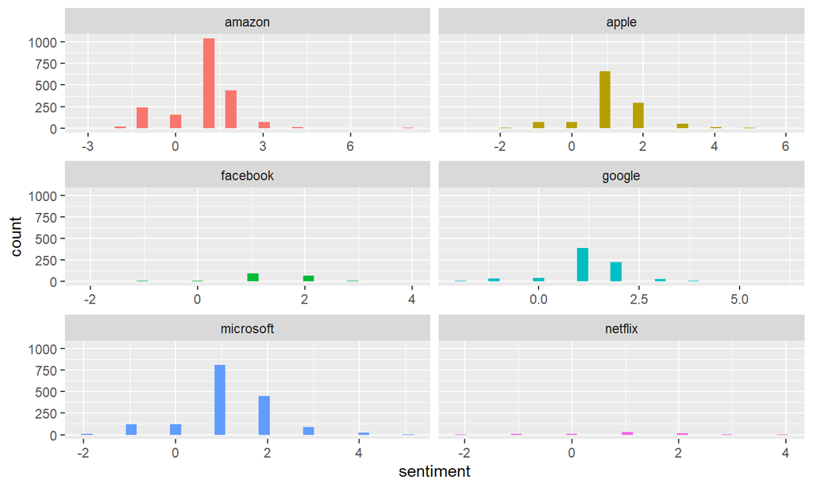

```r
ggplot(reviews_sentiment, aes(sentiment, fill = company)) +
  geom_histogram(show.legend = FALSE)  +
  facet_wrap(~company, ncol = 2, scales = "free_x")
```

## Palabras positivas y negativas más frecuentes

Analizamoslos términos positivos y negativos por separado

```r
bing_word_counts <- tidy_reviews %>%
  inner_join(get_sentiments("bing")) %>%
  count(word, sentiment, sort = TRUE) %>%
  ungroup()
bing_word_counts
```

```
## # A tibble: 693 x 3
##    word     sentiment     n
##    <chr>    <chr>     <int>
##  1 great    positive   1718
##  2 work     positive   1569
##  3 good     positive   1010
##  4 best     positive    326
##  5 amazing  positive    214
##  6 awesome  positive    169
##  7 benefits positive    141
##  8 fun      positive    117
##  9 hard     negative    115
## 10 bad      negative    114
## # ... with 683 more rows
```

La siguiente gráfica muestra como contribuyen los términos más frecuentes al sentimiento:

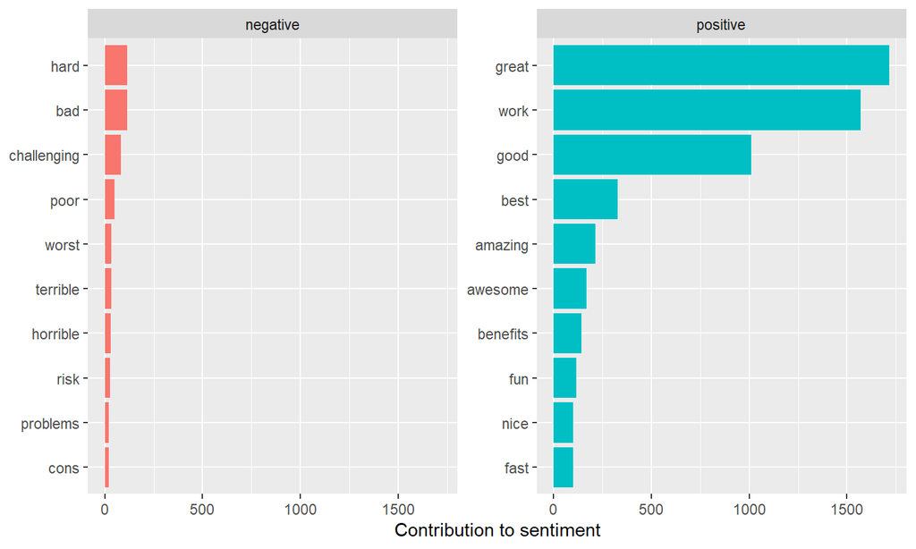

```r
bing_word_counts %>%
  group_by(sentiment) %>%
  slice_max(n, n = 10) %>%
  ungroup() %>%
  mutate(word = reorder(word, n)) %>%
  ggplot(aes(n, word, fill = sentiment)) +
  geom_col(show.legend = FALSE) +
  facet_wrap(~sentiment, scales = "free_y") +
  labs(x = "Contribution to sentiment",
       y = NULL)
```

## Nubes de palabras

Es preciso instalar el paquete `wordcloud` que dependiendo de la versión de R puede ser un poco complejo. Probar primero:

- install.packages(“slam”)
- install.packages(“wordcloud”)

Si no funciona hay que instalar primero las Rtools

- Como instalar las RTools: https://cran.r-project.org/bin/windows/Rtools/rtools40.html

Recordar realizar el paso de actualizar el `PATH` y reiniciar `R`

Instalar el paquete `devtools`

- `install.packages("devtools")`

y finalmente instalar desde la consola de RStudio: [`wordcloud`](https://cran.r-project.org/web/packages/wordcloud/readme/README.html)

- `devtools::install_github("ifellows/wordcloud")`

Una vez instalado el paquete, visualizar una nube de palabras es muy sencillo:

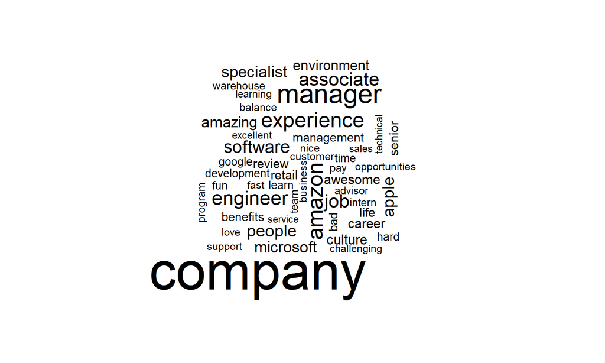

```r
library(wordcloud)

tidy_reviews %>%
  anti_join(stop_words) %>%
  count(word) %>%
  with(wordcloud(word, n, max.words = 50))
```

Podemos incorporar palabras prohibidas que quisieramos eliminar

```r
custom_stop_words <- bind_rows(tibble(
                                word = c("company"),
                                lexicon = c("propio")
                               ),
                               stop_words)
custom_stop_words
```

```
## # A tibble: 1,150 x 2
##   word    lexicon
##   <chr>   <chr>
## 1 company propio
## 2 a       SMART
## 3 a's     SMART
## 4 able    SMART
## 5 about   SMART
## 6 above   SMART
## # ... with 1,144 more rows
```

Mostramos la nueva nube de palabras habiendo eliminado `company`

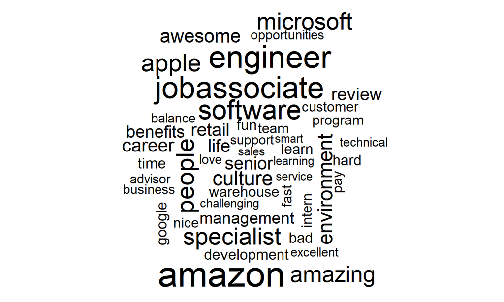

```r
tidy_reviews %>%
  anti_join(custom_stop_words) %>%
  count(word) %>%
  with(wordcloud(word, n, max.words = 50))
```

Mismo gráfico pero destacando los términos positivo y negativo

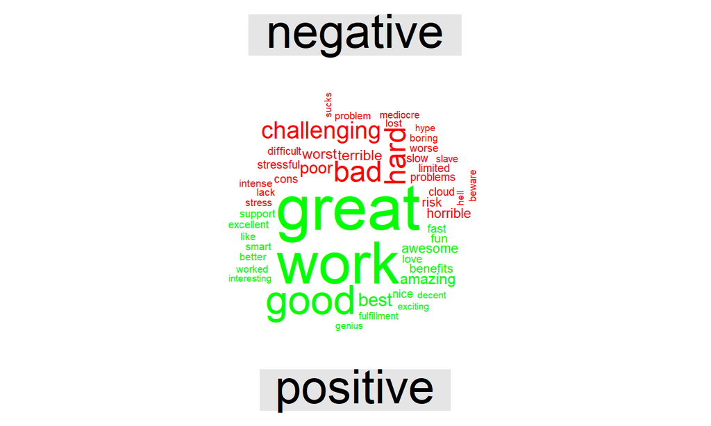

```r
tidy_reviews %>%
  inner_join(get_sentiments("bing")) %>%
  count(word, sentiment, sort = TRUE) %>%
  acast(word ~ sentiment, value.var = "n", fill = 0) %>%
  comparison.cloud(colors = c("red", "green"),
                   max.words = 50)
```